# Session 11: From GLMs to GLMMs

Why (and how) we model non-independent data

Simon Stephan

Linear Models and their Application in R

12 November 2026

## Where we are

01IntroductionWhat is a statistical model?

02Simple regressionHow does one variable predict another?

03Multiple regressionWhat if there are several predictors?

04Categorical predictorsWhat if a predictor is a category?

05InteractionsWhat if the effect of one predictor depends on another?

06The t-test as a linear modelIsn't a t-test something else?

07ANOVA as a linear modelAnd what about ANOVA?

08Model buildingHow do I build a good model?

09Model selectionHow do I select the best model?

10GLMWhat to do if the DV is not normal?

11GLMMWhat to do if observations are not independent?

↳ today: why & how · then: practical on your laptops

**Today’s goals**

After this session you can …

1. explain why repeated observations violate the **independence** assumption
2. describe what a **random intercept** and a **random slope** are
3. specify a simple GLMM in R using `lme4`, and say how its result differs from a GLM

You already know all other concepts we need today: logistic regression, link functions, centred predictors.

## Our question: do chimpanzees understand mechanisms?

- **Safe box:** structure guarantees delivery
- **Risky box:** grape seems to get stuck (sometimes)
- In fact, **both boxes always deliver**

**RQ1:** Do chimps **prefer the Safe box** in session 1?  
**RQ2:** Does this preference **change over sessions**?  
(Curiosity → below 50%? Indifference → towards 50%? Utility → stays Safe?)

Today: a small example with 10 chimps × 4 sessions × 10 trials · response: choice (1 = Safe, 0 = Risky)

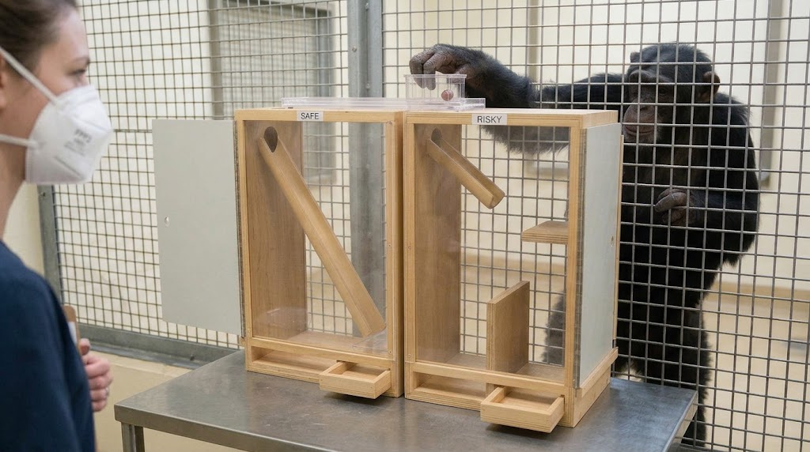

Illustration (AI-generated)

Ongoing study with the MPI EVA, Leipzig; preregistered. The data do not exist yet: the numbers today are **simulated to illustrate key points**, not a prediction of our results.

## Example data

[figure not shown]

## Let’s plot the data

[figure not shown]

## The model we already know: a GLM

[figure not shown]

**Question to you:** Why do we need a **generalized** linear model here, and not a standard linear model?

**Question to you:** Why do we need a **generalized** linear model here, and not a standard linear model?

The response is **binary** (1 = Safe, 0 = Risky). A linear model assumes normally distributed residuals and can predict values below 0% or above 100%. A **logistic GLM** (binomial distribution, logit link) keeps predictions between 0 and 1.

```r
glm.mod <- glm(choice ~ session_c,
               family = binomial,
               data = trials)
summary(glm.mod)
```

```r
glm.mod <- glm(choice ~ session_c,
               family = binomial,
               data = trials)
summary(glm.mod)
```

```
Coefficients:
            Estimate Std. Error z value Pr(>|z|)
(Intercept)   0.5385     0.1722   3.127  0.00177 **
session_c    -0.1761     0.0910  -1.936  0.05292 .
```

```r
glm.mod <- glm(choice ~ session_c,
               family = binomial,
               data = trials)
summary(glm.mod)
```

```
Coefficients:
            Estimate Std. Error z value Pr(>|z|)
(Intercept)   0.5385     0.1722   3.127  0.00177 **
session_c    -0.1761     0.0910  -1.936  0.05292 .
```

**RQ1:** intercept = 0.54 (63% Safe in session 1), *p* = .002

```r
glm.mod <- glm(choice ~ session_c,
               family = binomial,
               data = trials)
summary(glm.mod)
```

```
Coefficients:
            Estimate Std. Error z value Pr(>|z|)
(Intercept)   0.5385     0.1722   3.127  0.00177 **
session_c    -0.1761     0.0910  -1.936  0.05292 .
```

**RQ1:** intercept = 0.54 (63% Safe in session 1), *p* = .002  
**RQ2:** slope = −0.18 per session, *p* = .053 → not significant

## Pseudo-replication

[figure not shown]

## GLM vs. GLMM

[figure not shown]

## A GLMM with random intercepts

[figure not shown]

Each chimp gets its own line (dashed); blue = average chimp.

```r
library(lme4)
ri.mod <- glmer(choice ~ session_c + (1 | chimp),
                family = binomial, data = trials)
summary(ri.mod)
```

```r
library(lme4)
ri.mod <- glmer(choice ~ session_c + (1 | chimp),
                family = binomial, data = trials)
summary(ri.mod)
```

```
Random effects:
 Groups Name        Variance Std.Dev.
 chimp  (Intercept) 4.818    2.195
Number of obs: 400, groups:  chimp, 10

Fixed effects:
            Estimate Std. Error z value Pr(>|z|)
(Intercept)   0.8376     0.7396   1.133  0.25740
session_c    -0.3286     0.1242  -2.645  0.00816 **
```

**Random effects output:** The model estimates the SD of the chimp-specific intercepts, yielding a measure of how much individuals vary in their baseline preference.

```r
library(lme4)
ri.mod <- glmer(choice ~ session_c + (1 | chimp),
                family = binomial, data = trials)
summary(ri.mod)
```

```
Random effects:
 Groups Name        Variance Std.Dev.
 chimp  (Intercept) 4.818    2.195
Number of obs: 400, groups:  chimp, 10

Fixed effects:
            Estimate Std. Error z value Pr(>|z|)
(Intercept)   0.8376     0.7396   1.133  0.25740
session_c    -0.3286     0.1242  -2.645  0.00816 **
```

**Fixed effects output:** the blue line, the *average chimp*: a chimp whose random intercept is 0

- **Intercept** 0.84 (*p* = .257): its log-odds of Safe in session 1 (70%). Random intercepts are deviations *from this value*, so 0 deviation gives 0.84, not 0.
- **Slope** −0.33 (*p* = .008): its change per session

```r
library(lme4)
ri.mod <- glmer(choice ~ session_c + (1 | chimp),
                family = binomial, data = trials)
summary(ri.mod)
```

```
Random effects:
 Groups Name        Variance Std.Dev.
 chimp  (Intercept) 4.818    2.195
Number of obs: 400, groups:  chimp, 10

Fixed effects:
            Estimate Std. Error z value Pr(>|z|)
(Intercept)   0.8376     0.7396   1.133  0.25740
session_c    -0.3286     0.1242  -2.645  0.00816 **
```

GLMM: b = −0.33 vs. GLM: b = −0.18: the GLM line is flatter because pooling chimps at very different levels **flattens the curve** (previous slide).

## Random slopes: each chimp its own slope

[figure not shown]

So far: one shared slope. The dashed lines run in parallel.

**But chimps also differ in how their preference changes.**

Now each chimp also gets its own slope:

```r
rs.mod <- glmer(choice ~ session_c +
                  (1 + session_c | chimp),
                family = binomial, data = trials)
```

```
Random effects:
 Groups Name        Variance Std.Dev. Corr
 chimp  (Intercept) 5.3757   2.3185
        session_c   0.0922   0.3036   -0.26
Number of obs: 400, groups:  chimp, 10

Fixed effects:
            Estimate Std. Error z value Pr(>|z|)
(Intercept)   0.9113     0.7856   1.160   0.2461
session_c    -0.3629     0.1674  -2.169   0.0301 *
```

[figure not shown]

## The full model in R

```r
rs.mod <- glmer(
  choice ~ session_c + (1 + session_c | chimp),
  family  = binomial, data = trials,
  control = glmerControl(optimizer = "bobyqa"))
summary(rs.mod)
```

```
Random effects:
 Groups Name        Variance Std.Dev. Corr
 chimp  (Intercept) 5.3757   2.3185
        session_c   0.0922   0.3036   -0.26
Number of obs: 400, groups:  chimp, 10

Fixed effects:
            Estimate Std. Error z value Pr(>|z|)
(Intercept)   0.9113     0.7856   1.160   0.2461
session_c    -0.3629     0.1674  -2.169   0.0301 *
```

|  | RQ1: intercept | RQ2: session |
| --- | --- | --- |
| GLM | 0.54 (p = .002) | −0.18 (p = .053) |
| GLMM: random intercepts | 0.84 (p = .257) | −0.33 (p = .008) |
| GLMM: + random slopes | 0.91 (p = .246) | −0.36 (p = .030) |

**RQ1:** only the GLM finds a Safe preference in session 1: it treats 400 choices as independent and is overconfident.  
**RQ2:** the GLM misses the decline; both GLMMs find it. With random slopes, the uncertainty is larger, because chimps also differ in their slopes.

## Take-home

1. Repeated observations → non-independence → **pseudo-replication** if ignored
2. **Random intercept:** each individual gets its own level and we estimate the variance of it
3. **Random slope:** each individual also gets its own response to a predictor
4. GLM and GLMM can disagree: ignoring individual differences can make you **overconfident**, or, with large baseline differences, **miss real effects**

**Fixed effects:** estimated for the average individual (e.g., the average chimp’s intercept and slope)

**Random effects:** how individuals deviate from the average; we estimate the variance (SD) of these deviations

**Practical:** your turn, on your laptops: real DPZ field data on wild Guinea baboons (Dal Pesco et al., 2026): maternal behaviour over infant development (a Poisson GLMM)

**Course website:** slides, data and exercises: [simonstephan31.github.io/cbbstats](https://simonstephan31.github.io/cbbstats/)

## Back-up: chimp as a fixed factor or as a random effect

[figure not shown]

```r
# standard solution: chimp as a dummy-coded factor
glm(choice ~ session_c + chimp,
    family = binomial, data = trials)
# GLMM solution: chimp as a random effect
glmer(choice ~ session_c + (1 | chimp),
      family = binomial, data = trials)
```

|  | Standard: GLM + chimp factor | GLMM: random effect |
| --- | --- | --- |
| Intercept | −0.13 | 0.84 |
| Session | −0.34 | −0.33 |
| Chimp 1 |  | −0.96 |
| Chimp 2 | 2.89 | 1.80 |
| Chimp 3 | −2.37 | −3.05 |
| Chimp 4 | 0.95 | −0.03 |
| Chimp 5 | 1.64 | 0.64 |
| Chimp 6 | −3.09 | −3.50 |
| Chimp 7 | 4.37 | 2.89 |
| Chimp 8 | −0.12 | −1.07 |
| Chimp 9 | 2.89 | 1.80 |
| Chimp 10 | 2.43 | 1.38 |

**Standard solution:** results only for **these 10 chimps**. **GLMM:** chimps as a **sample** from the population, **one** extra parameter (σ).

## Back-up: why not just dummy-code the chimps?

1. **Inference only about these 10 chimps:** no estimate of how chimps vary in the population, so results do not generalize.
2. **Many parameters:** one per chimp (here 9), twice as many with individual slopes (chimp × session); with treatment coding, the session effect is then **chimp 1’s slope**, not the average chimp’s.
3. **Separation:** a chimp that always chooses the same box gets an infinite estimate; near-separation gives extreme values (chimp 7 vs. chimp 1: 4.37; GLMM: 3.86).
4. **No partial pooling:** each chimp is estimated from its own data only; a GLMM shrinks uncertain chimps towards the average.
5. **Between-chimp predictors** (sex, age, rearing history) are aliased with the chimp factor and **cannot be estimated**.
6. **Still pseudo-replication** if chimps differ in their slopes: the session effect gets too small SEs (Schielzeth & Forstmeier, 2009; Barr et al., 2013).

## Back-up: was this just luck? 1000 simulations

[figure not shown]

- **RQ1:** the GLM finds a Safe preference that does not exist in 48% of runs (dashed line: the nominal 5%).
- **RQ2:** GLM and GLMM can disagree. With large baseline differences and a **similar trend in all chimps**, the GLM misses the decline more often (less power). If chimps also differ in their slopes, the full model is about as cautious as the GLM.